# Project: Identify Customer Segments

In this project, you will apply unsupervised learning techniques to identify segments of the population that form the core customer base for a mail-order sales company in Germany. These segments can then be used to direct marketing campaigns towards audiences that will have the highest expected rate of returns. The data that you will use has been provided by our partners at Bertelsmann Arvato Analytics, and represents a real-life data science task.

This notebook will help you complete this task by providing a framework within which you will perform your analysis steps. In each step of the project, you will see some text describing the subtask that you will perform, followed by one or more code cells for you to complete your work. **Feel free to add additional code and markdown cells as you go along so that you can explore everything in precise chunks.** The code cells provided in the base template will outline only the major tasks, and will usually not be enough to cover all of the minor tasks that comprise it.

It should be noted that while there will be precise guidelines on how you should handle certain tasks in the project, there will also be places where an exact specification is not provided. **There will be times in the project where you will need to make and justify your own decisions on how to treat the data.** These are places where there may not be only one way to handle the data. In real-life tasks, there may be many valid ways to approach an analysis task. One of the most important things you can do is clearly document your approach so that other scientists can understand the decisions you've made.

At the end of most sections, there will be a Markdown cell labeled **Discussion**. In these cells, you will report your findings for the completed section, as well as document the decisions that you made in your approach to each subtask. **Your project will be evaluated not just on the code used to complete the tasks outlined, but also your communication about your observations and conclusions at each stage.**

```python
# import libraries here; add more as necessary
import numpy as np
import pandas as pd
import matplotlib.pyplot as plt
import seaborn as sns
from sklearn.preprocessing import Imputer, StandardScaler
from sklearn.decomposition import PCA
from sklearn.cluster import KMeans

# magic word for producing visualizations in notebook
%matplotlib inline
```

### Step 0: Load the Data

Each row of the demographics files represents a single person, but also includes information outside of individuals, including information about their household, building, and neighborhood. You will use this information to cluster the general population into groups with similar demographic properties. Then, you will see how the people in the customers dataset fit into those created clusters. The hope here is that certain clusters are over-represented in the customers data, as compared to the general population; those over-represented clusters will be assumed to be part of the core userbase. This information can then be used for further applications, such as targeting for a marketing campaign.

To start off with, load in the demographics data for the general population into a pandas DataFrame, and do the same for the feature attributes summary. Note for all of the `.csv` data files in this project: they're semicolon (`;`) delimited, so you'll need an additional argument in your [`read_csv()`](https://pandas.pydata.org/pandas-docs/stable/generated/pandas.read_csv.html) call to read in the data properly. Also, considering the size of the main dataset, it may take some time for it to load completely.

Once the dataset is loaded, it's recommended that you take a little bit of time just browsing the general structure of the dataset and feature summary file. You'll be getting deep into the innards of the cleaning in the first major step of the project, so gaining some general familiarity can help you get your bearings.

```python
# Load in the general demographics data.
azdias = pd.read_csv('Udacity_AZDIAS_Subset.csv', sep=';')

# Load in the feature summary file.
feat_info = pd.read_csv('AZDIAS_Feature_Summary.csv', sep=';')
```

```python
# Check the structure of the data after it's loaded (e.g. print the number of
# rows and columns, print the first few rows).
print('azdias shape (rows/columns): %s' % str(azdias.shape) )
print('First few rows of azdias dataset:')
azdias.head()
```

```
azdias shape (rows/columns): (891221, 85)
First few rows of azdias dataset:
```

|  | AGER_TYP | ALTERSKATEGORIE_GROB | ANREDE_KZ | CJT_GESAMTTYP | FINANZ_MINIMALIST | FINANZ_SPARER | FINANZ_VORSORGER | FINANZ_ANLEGER | FINANZ_UNAUFFAELLIGER | FINANZ_HAUSBAUER | ... | PLZ8_ANTG1 | PLZ8_ANTG2 | PLZ8_ANTG3 | PLZ8_ANTG4 | PLZ8_BAUMAX | PLZ8_HHZ | PLZ8_GBZ | ARBEIT | ORTSGR_KLS9 | RELAT_AB |
| --- | --- | --- | --- | --- | --- | --- | --- | --- | --- | --- | --- | --- | --- | --- | --- | --- | --- | --- | --- | --- | --- |
| 0 | -1 | 2 | 1 | 2.0 | 3 | 4 | 3 | 5 | 5 | 3 | ... | NaN | NaN | NaN | NaN | NaN | NaN | NaN | NaN | NaN | NaN |
| 1 | -1 | 1 | 2 | 5.0 | 1 | 5 | 2 | 5 | 4 | 5 | ... | 2.0 | 3.0 | 2.0 | 1.0 | 1.0 | 5.0 | 4.0 | 3.0 | 5.0 | 4.0 |
| 2 | -1 | 3 | 2 | 3.0 | 1 | 4 | 1 | 2 | 3 | 5 | ... | 3.0 | 3.0 | 1.0 | 0.0 | 1.0 | 4.0 | 4.0 | 3.0 | 5.0 | 2.0 |
| 3 | 2 | 4 | 2 | 2.0 | 4 | 2 | 5 | 2 | 1 | 2 | ... | 2.0 | 2.0 | 2.0 | 0.0 | 1.0 | 3.0 | 4.0 | 2.0 | 3.0 | 3.0 |
| 4 | -1 | 3 | 1 | 5.0 | 4 | 3 | 4 | 1 | 3 | 2 | ... | 2.0 | 4.0 | 2.0 | 1.0 | 2.0 | 3.0 | 3.0 | 4.0 | 6.0 | 5.0 |

5 rows × 85 columns

```python
# Check what the feature summary file contains
print('Features information file:')
feat_info
```

```
Features information file:
```

|  | attribute | information_level | type | missing_or_unknown |
| --- | --- | --- | --- | --- |
| 0 | AGER_TYP | person | categorical | [-1,0] |
| 1 | ALTERSKATEGORIE_GROB | person | ordinal | [-1,0,9] |
| 2 | ANREDE_KZ | person | categorical | [-1,0] |
| 3 | CJT_GESAMTTYP | person | categorical | [0] |
| 4 | FINANZ_MINIMALIST | person | ordinal | [-1] |
| 5 | FINANZ_SPARER | person | ordinal | [-1] |
| 6 | FINANZ_VORSORGER | person | ordinal | [-1] |
| 7 | FINANZ_ANLEGER | person | ordinal | [-1] |
| 8 | FINANZ_UNAUFFAELLIGER | person | ordinal | [-1] |
| 9 | FINANZ_HAUSBAUER | person | ordinal | [-1] |
| 10 | FINANZTYP | person | categorical | [-1] |
| 11 | GEBURTSJAHR | person | numeric | [0] |
| 12 | GFK_URLAUBERTYP | person | categorical | [] |
| 13 | GREEN_AVANTGARDE | person | categorical | [] |
| 14 | HEALTH_TYP | person | ordinal | [-1,0] |
| 15 | LP_LEBENSPHASE_FEIN | person | mixed | [0] |
| 16 | LP_LEBENSPHASE_GROB | person | mixed | [0] |
| 17 | LP_FAMILIE_FEIN | person | categorical | [0] |
| 18 | LP_FAMILIE_GROB | person | categorical | [0] |
| 19 | LP_STATUS_FEIN | person | categorical | [0] |
| 20 | LP_STATUS_GROB | person | categorical | [0] |
| 21 | NATIONALITAET_KZ | person | categorical | [-1,0] |
| 22 | PRAEGENDE_JUGENDJAHRE | person | mixed | [-1,0] |
| 23 | RETOURTYP_BK_S | person | ordinal | [0] |
| 24 | SEMIO_SOZ | person | ordinal | [-1,9] |
| 25 | SEMIO_FAM | person | ordinal | [-1,9] |
| 26 | SEMIO_REL | person | ordinal | [-1,9] |
| 27 | SEMIO_MAT | person | ordinal | [-1,9] |
| 28 | SEMIO_VERT | person | ordinal | [-1,9] |
| 29 | SEMIO_LUST | person | ordinal | [-1,9] |
| ... | ... | ... | ... | ... |
| 55 | OST_WEST_KZ | building | categorical | [-1] |
| 56 | WOHNLAGE | building | mixed | [-1] |
| 57 | CAMEO_DEUG_2015 | microcell_rr4 | categorical | [-1,X] |
| 58 | CAMEO_DEU_2015 | microcell_rr4 | categorical | [XX] |
| 59 | CAMEO_INTL_2015 | microcell_rr4 | mixed | [-1,XX] |
| 60 | KBA05_ANTG1 | microcell_rr3 | ordinal | [-1] |
| 61 | KBA05_ANTG2 | microcell_rr3 | ordinal | [-1] |
| 62 | KBA05_ANTG3 | microcell_rr3 | ordinal | [-1] |
| 63 | KBA05_ANTG4 | microcell_rr3 | ordinal | [-1] |
| 64 | KBA05_BAUMAX | microcell_rr3 | mixed | [-1,0] |
| 65 | KBA05_GBZ | microcell_rr3 | ordinal | [-1,0] |
| 66 | BALLRAUM | postcode | ordinal | [-1] |
| 67 | EWDICHTE | postcode | ordinal | [-1] |
| 68 | INNENSTADT | postcode | ordinal | [-1] |
| 69 | GEBAEUDETYP_RASTER | region_rr1 | ordinal | [] |
| 70 | KKK | region_rr1 | ordinal | [-1,0] |
| 71 | MOBI_REGIO | region_rr1 | ordinal | [] |
| 72 | ONLINE_AFFINITAET | region_rr1 | ordinal | [] |
| 73 | REGIOTYP | region_rr1 | ordinal | [-1,0] |
| 74 | KBA13_ANZAHL_PKW | macrocell_plz8 | numeric | [] |
| 75 | PLZ8_ANTG1 | macrocell_plz8 | ordinal | [-1] |
| 76 | PLZ8_ANTG2 | macrocell_plz8 | ordinal | [-1] |
| 77 | PLZ8_ANTG3 | macrocell_plz8 | ordinal | [-1] |
| 78 | PLZ8_ANTG4 | macrocell_plz8 | ordinal | [-1] |
| 79 | PLZ8_BAUMAX | macrocell_plz8 | mixed | [-1,0] |
| 80 | PLZ8_HHZ | macrocell_plz8 | ordinal | [-1] |
| 81 | PLZ8_GBZ | macrocell_plz8 | ordinal | [-1] |
| 82 | ARBEIT | community | ordinal | [-1,9] |
| 83 | ORTSGR_KLS9 | community | ordinal | [-1,0] |
| 84 | RELAT_AB | community | ordinal | [-1,9] |

85 rows × 4 columns

> **Tip**: Add additional cells to keep everything in reasonably-sized chunks! Keyboard shortcut `esc --> a` (press escape to enter command mode, then press the 'A' key) adds a new cell before the active cell, and `esc --> b` adds a new cell after the active cell. If you need to convert an active cell to a markdown cell, use `esc --> m` and to convert to a code cell, use `esc --> y`.

## Step 1: Preprocessing

### Step 1.1: Assess Missing Data

The feature summary file contains a summary of properties for each demographics data column. You will use this file to help you make cleaning decisions during this stage of the project. First of all, you should assess the demographics data in terms of missing data. Pay attention to the following points as you perform your analysis, and take notes on what you observe. Make sure that you fill in the **Discussion** cell with your findings and decisions at the end of each step that has one!

#### Step 1.1.1: Convert Missing Value Codes to NaNs

The fourth column of the feature attributes summary (loaded in above as `feat_info`) documents the codes from the data dictionary that indicate missing or unknown data. While the file encodes this as a list (e.g. `[-1,0]`), this will get read in as a string object. You'll need to do a little bit of parsing to make use of it to identify and clean the data. Convert data that matches a 'missing' or 'unknown' value code into a numpy NaN value. You might want to see how much data takes on a 'missing' or 'unknown' code, and how much data is naturally missing, as a point of interest.

**As one more reminder, you are encouraged to add additional cells to break up your analysis into manageable chunks.**

```python
# First, i'm creating a copy of our database, in case I corrupt something
azdias_cleaned = azdias.copy()
```

```python
print( azdias_cleaned.head() )
```

```
   AGER_TYP  ALTERSKATEGORIE_GROB  ANREDE_KZ  CJT_GESAMTTYP  \
0        -1                     2          1            2.0
1        -1                     1          2            5.0
2        -1                     3          2            3.0
3         2                     4          2            2.0
4        -1                     3          1            5.0

   FINANZ_MINIMALIST  FINANZ_SPARER  FINANZ_VORSORGER  FINANZ_ANLEGER  \
0                  3              4                 3               5
1                  1              5                 2               5
2                  1              4                 1               2
3                  4              2                 5               2
4                  4              3                 4               1

   FINANZ_UNAUFFAELLIGER  FINANZ_HAUSBAUER    ...     PLZ8_ANTG1  PLZ8_ANTG2  \
```

[output cut: 21 more lines]

```python
# Define a fuction that converts a list of strings where some of them are "integer strings" and some charachter strings
# into a list of actual integers and strings. This will be needed later!
def ModifyEmptyCodesListForPandasReplaceFunc( inputList ):
    outputList = []

    for val in inputList:
        try:
            outputList.append(int(val))
        except Exception as inst: # If letter, will create an exception, and then we just add it as is
            outputList.append(val)

    return outputList
```

```python
# Identify missing or unknown data values and convert them to NaNs.
for columnIdx in range( 0, azdias_cleaned.shape[1] ):

    # Get the "empty codes" in list format for current column in azdias
    empty_code_list = feat_info.iloc[:,3][columnIdx].strip('][').split(',')

    # Modify list -> pandas.replace function needs it
    empty_code_list = ModifyEmptyCodesListForPandasReplaceFunc( empty_code_list )

    # Attempt to replace values using modified list
    azdias_cleaned[ azdias_cleaned.columns[columnIdx] ].replace( empty_code_list, np.NaN, inplace=True )

    print('Cleaned azdias_cleaned column %d. Empty values: %s were replace by NaN' % ( columnIdx, feat_info.iloc[:,3][columnIdx] ))
```

```
Cleaned azdias_cleaned column 0. Empty values: [-1,0] were replace by NaN
Cleaned azdias_cleaned column 1. Empty values: [-1,0,9] were replace by NaN
Cleaned azdias_cleaned column 2. Empty values: [-1,0] were replace by NaN
Cleaned azdias_cleaned column 3. Empty values: [0] were replace by NaN
Cleaned azdias_cleaned column 4. Empty values: [-1] were replace by NaN
Cleaned azdias_cleaned column 5. Empty values: [-1] were replace by NaN
Cleaned azdias_cleaned column 6. Empty values: [-1] were replace by NaN
Cleaned azdias_cleaned column 7. Empty values: [-1] were replace by NaN
Cleaned azdias_cleaned column 8. Empty values: [-1] were replace by NaN
Cleaned azdias_cleaned column 9. Empty values: [-1] were replace by NaN
Cleaned azdias_cleaned column 10. Empty values: [-1] were replace by NaN
Cleaned azdias_cleaned column 11. Empty values: [0] were replace by NaN
Cleaned azdias_cleaned column 12. Empty values: [] were replace by NaN
Cleaned azdias_cleaned column 13. Empty values: [] were replace by NaN
Cleaned azdias_cleaned column 14. Empty values: [-1,0] were replace by NaN
Cleaned azdias_cleaned column 15. Empty values: [0] were replace by NaN
Cleaned azdias_cleaned column 16. Empty values: [0] were replace by NaN
Cleaned azdias_cleaned column 17. Empty values: [0] were replace by NaN
Cleaned azdias_cleaned column 18. Empty values: [0] were replace by NaN
Cleaned azdias_cleaned column 19. Empty values: [0] were replace by NaN
Cleaned azdias_cleaned column 20. Empty values: [0] were replace by NaN
Cleaned azdias_cleaned column 21. Empty values: [-1,0] were replace by NaN
Cleaned azdias_cleaned column 22. Empty values: [-1,0] were replace by NaN
Cleaned azdias_cleaned column 23. Empty values: [0] were replace by NaN
Cleaned azdias_cleaned column 24. Empty values: [-1,9] were replace by NaN
Cleaned azdias_cleaned column 25. Empty values: [-1,9] were replace by NaN
Cleaned azdias_cleaned column 26. Empty values: [-1,9] were replace by NaN
Cleaned azdias_cleaned column 27. Empty values: [-1,9] were replace by NaN
Cleaned azdias_cleaned column 28. Empty values: [-1,9] were replace by NaN
Cleaned azdias_cleaned column 29. Empty values: [-1,9] were replace by NaN
Cleaned azdias_cleaned column 30. Empty values: [-1,9] were replace by NaN
Cleaned azdias_cleaned column 31. Empty values: [-1,9] were replace by NaN
Cleaned azdias_cleaned column 32. Empty values: [-1,9] were replace by NaN
Cleaned azdias_cleaned column 33. Empty values: [-1,9] were replace by NaN
Cleaned azdias_cleaned column 34. Empty values: [-1,9] were replace by NaN
Cleaned azdias_cleaned column 35. Empty values: [-1,9] were replace by NaN
Cleaned azdias_cleaned column 36. Empty values: [-1,9] were replace by NaN
Cleaned azdias_cleaned column 37. Empty values: [-1,9] were replace by NaN
Cleaned azdias_cleaned column 38. Empty values: [-1] were replace by NaN
Cleaned azdias_cleaned column 39. Empty values: [-1] were replace by NaN
```

[output cut: 30 more lines]

```
Cleaned azdias_cleaned column 70. Empty values: [-1,0] were replace by NaN
Cleaned azdias_cleaned column 71. Empty values: [] were replace by NaN
Cleaned azdias_cleaned column 72. Empty values: [] were replace by NaN
Cleaned azdias_cleaned column 73. Empty values: [-1,0] were replace by NaN
Cleaned azdias_cleaned column 74. Empty values: [] were replace by NaN
Cleaned azdias_cleaned column 75. Empty values: [-1] were replace by NaN
Cleaned azdias_cleaned column 76. Empty values: [-1] were replace by NaN
Cleaned azdias_cleaned column 77. Empty values: [-1] were replace by NaN
Cleaned azdias_cleaned column 78. Empty values: [-1] were replace by NaN
Cleaned azdias_cleaned column 79. Empty values: [-1,0] were replace by NaN
Cleaned azdias_cleaned column 80. Empty values: [-1] were replace by NaN
Cleaned azdias_cleaned column 81. Empty values: [-1] were replace by NaN
Cleaned azdias_cleaned column 82. Empty values: [-1,9] were replace by NaN
Cleaned azdias_cleaned column 83. Empty values: [-1,0] were replace by NaN
Cleaned azdias_cleaned column 84. Empty values: [-1,9] were replace by NaN
```

```python
# Small verification I did to see if the 'XX' values were indeed replaced by NaN in column 58
tmp = azdias_cleaned.loc[azdias_cleaned['CAMEO_DEU_2015'] == 'XX']
print( tmp['CAMEO_DEU_2015'])
```

```
Series([], Name: CAMEO_DEU_2015, dtype: object)
```

#### Step 1.1.2: Assess Missing Data in Each Column

How much missing data is present in each column? There are a few columns that are outliers in terms of the proportion of values that are missing. You will want to use matplotlib's [`hist()`](https://matplotlib.org/api/_as_gen/matplotlib.pyplot.hist.html) function to visualize the distribution of missing value counts to find these columns. Identify and document these columns. While some of these columns might have justifications for keeping or re-encoding the data, for this project you should just remove them from the dataframe. (Feel free to make remarks about these outlier columns in the discussion, however!)

For the remaining features, are there any patterns in which columns have, or share, missing data?

```
The outlier columns (>20% of values in column is missing ):
```

```
AGER_TYP        0.769554
GEBURTSJAHR     0.440203
TITEL_KZ        0.997576
ALTER_HH        0.348137
KK_KUNDENTYP    0.655967
KBA05_BAUMAX    0.534687
dtype: float64
```

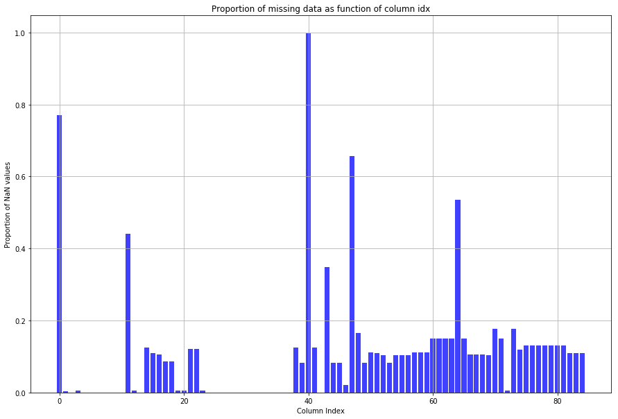

```python
# Caluclate proportion of NaNs per column
num_rows = azdias_cleaned.shape[0]
proprtion_of_NaN_per_column_series = ( num_rows - azdias_cleaned.count() ) / num_rows # Count finds the non NaN values...

# Visualize (I preferred a bar graph over histogram in this case )
plt.figure(figsize=(15, 10))
ax = plt.subplot(111)
ax.bar(range(0,azdias_cleaned.shape[1]),proprtion_of_NaN_per_column_series.values, facecolor='blue', alpha=0.75)
ax.set_xlabel("Column Index")
ax.set_ylabel("Proportion of NaN values")
plt.title('Proportion of missing data as function of column idx')
plt.grid()

# According to the bar graph I decided that the obvious outliers are those where the we have more than 20% NaN values.
outlier_th = 0.2
outlier_series = proprtion_of_NaN_per_column_series[ proprtion_of_NaN_per_column_series > outlier_th]
print("The outlier columns (>20% of values in column is missing ):")
outlier_series
```

```python
# Remove the outlier columns from the dataset. (You'll perform other data
# engineering tasks such as re-encoding and imputation later.)
azdias_cleaned.drop(['AGER_TYP', 'GEBURTSJAHR','TITEL_KZ', 'ALTER_HH', 'KK_KUNDENTYP', 'KBA05_BAUMAX'], axis=1, inplace=True)
```

```python
# Verify that columns were dropped
azdias_cleaned.head(1)
```

|  | ALTERSKATEGORIE_GROB | ANREDE_KZ | CJT_GESAMTTYP | FINANZ_MINIMALIST | FINANZ_SPARER | FINANZ_VORSORGER | FINANZ_ANLEGER | FINANZ_UNAUFFAELLIGER | FINANZ_HAUSBAUER | FINANZTYP | ... | PLZ8_ANTG1 | PLZ8_ANTG2 | PLZ8_ANTG3 | PLZ8_ANTG4 | PLZ8_BAUMAX | PLZ8_HHZ | PLZ8_GBZ | ARBEIT | ORTSGR_KLS9 | RELAT_AB |
| --- | --- | --- | --- | --- | --- | --- | --- | --- | --- | --- | --- | --- | --- | --- | --- | --- | --- | --- | --- | --- | --- |
| 0 | 2.0 | 1 | 2.0 | 3 | 4 | 3 | 5 | 5 | 3 | 4 | ... | NaN | NaN | NaN | NaN | NaN | NaN | NaN | NaN | NaN | NaN |

1 rows × 79 columns

#### Discussion 1.1.2: Assess Missing Data in Each Column

(Double click this cell and replace this text with your own text, reporting your observations regarding the amount of missing data in each column. Are there any patterns in missing values? Which columns were removed from the dataset?)

#### Answer:

Just by looking at the data I see the following things:

1. The following columns should obviously go: ['AGER_TYP', 'GEBURTSJAHR', 'TITEL_KZ', ALTER_HH', 'KK_KUNDENTYP', 'KBA05_BAUMAX'] I took a look at the data dictionary. I won't copy paste the meaning of the fields here, but some are isoteric, such as AGER_TYP and TITEL_KZ. other relate to age of customer or date of birth, they could be important, but unfortunately, not enough reliable data inside. #### These columns are going to be removed from the data
1. Some statistics. Out of 85 columns, 61 have missing values to some degree. Out of the 61 columns with missing values, 6 had more than 20% missing data and deemed as outliers.
2. The rest of the columns with missing data: We can see a pattern that missing values come in "batches".. Meaning, that if data is missing, it'll miss in all the features grouped together. For example, Looking at the RR3 micro-cell features, we see that most of the features are missing the same rows. Example:

| Feature | NaN proportion |
| --- | --- |
| KBA05_ANTG1 | 0.149597 |
| KBA05_ANTG2 | 0.149597 |
| KBA05_ANTG3 | 0.149597 |
| KBA05_ANTG4 | 0.149597 |

Another example: (See next cell)

```python
azdias_cleaned.head(1) # You can see here that columns with NaN come as "blocks"
```

|  | ALTERSKATEGORIE_GROB | ANREDE_KZ | CJT_GESAMTTYP | FINANZ_MINIMALIST | FINANZ_SPARER | FINANZ_VORSORGER | FINANZ_ANLEGER | FINANZ_UNAUFFAELLIGER | FINANZ_HAUSBAUER | FINANZTYP | ... | PLZ8_ANTG1 | PLZ8_ANTG2 | PLZ8_ANTG3 | PLZ8_ANTG4 | PLZ8_BAUMAX | PLZ8_HHZ | PLZ8_GBZ | ARBEIT | ORTSGR_KLS9 | RELAT_AB |
| --- | --- | --- | --- | --- | --- | --- | --- | --- | --- | --- | --- | --- | --- | --- | --- | --- | --- | --- | --- | --- | --- |
| 0 | 2.0 | 1 | 2.0 | 3 | 4 | 3 | 5 | 5 | 3 | 4 | ... | NaN | NaN | NaN | NaN | NaN | NaN | NaN | NaN | NaN | NaN |

1 rows × 79 columns

#### Step 1.1.3: Assess Missing Data in Each Row

Now, you'll perform a similar assessment for the rows of the dataset. How much data is missing in each row? As with the columns, you should see some groups of points that have a very different numbers of missing values. Divide the data into two subsets: one for data points that are above some threshold for missing values, and a second subset for points below that threshold.

In order to know what to do with the outlier rows, we should see if the distribution of data values on columns that are not missing data (or are missing very little data) are similar or different between the two groups. Select at least five of these columns and compare the distribution of values.

- You can use seaborn's [`countplot()`](https://seaborn.pydata.org/generated/seaborn.countplot.html) function to create a bar chart of code frequencies and matplotlib's [`subplot()`](https://matplotlib.org/api/_as_gen/matplotlib.pyplot.subplot.html) function to put bar charts for the two subplots side by side.
- To reduce repeated code, you might want to write a function that can perform this comparison, taking as one of its arguments a column to be compared.

Depending on what you observe in your comparison, this will have implications on how you approach your conclusions later in the analysis. If the distributions of non-missing features look similar between the data with many missing values and the data with few or no missing values, then we could argue that simply dropping those points from the analysis won't present a major issue. On the other hand, if the data with many missing values looks very different from the data with few or no missing values, then we should make a note on those data as special. We'll revisit these data later on. **Either way, you should continue your analysis for now using just the subset of the data with few or no missing values.**

```python
# How much data is missing in each row of the dataset?
num_cols = azdias_cleaned.shape[1]
proprtion_of_NaN_per_row_series = ( num_cols - azdias_cleaned.count( 'columns' ) ) / num_cols # Count finds the non NaN values...
```

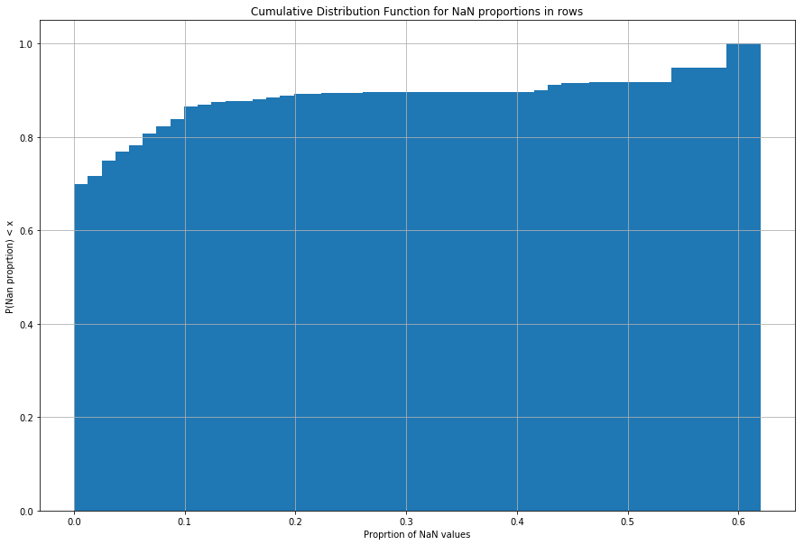

```python
# I want to choose the value for thresholding, so I wanted a CDF of the proportions of missing values.
# I'll choose the threshold as a value for which ~90% of proportions are below. Whatever is above (10%) is by definition
# an outlier (something that occurs 1 out of 10 times.)
plt.figure(figsize=(15, 10))
ax = plt.subplot(111)
plt.hist(proprtion_of_NaN_per_row_series, bins=100, cumulative=True, density=True)
ax.set_xlabel("Proprtion of NaN values")
ax.set_ylabel("P(Nan proprtion) < x")
plt.title('Cumulative Distribution Function for NaN proportions in rows')
plt.grid()
```

### Conclusion: We'll set the th=0.2 and plot distribution for rows above and rows below

```python
# Write code to divide the data into two subsets based on the number of missing
# values in each row.
# NOTICE: I divided based on the proportion of missing values.. It's equivalent.
th = 0.2

# Get indices for "good" values (low number of NaN values in the categories of the row)
idxs_data_set_below = proprtion_of_NaN_per_row_series < th
dataset_good = azdias_cleaned.loc[ idxs_data_set_below, : ].copy()

# Get indices for "bad" values (high number of NaN values in the categories of the row)
idxs_data_set_above = proprtion_of_NaN_per_row_series >= th
dataset_bad = azdias_cleaned.loc[ idxs_data_set_above, : ].copy()
```

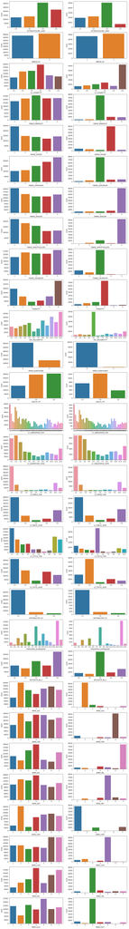

```python
# Compare the distribution of values for at least five columns where there are
# no or few missing values, between the two subsets.

# NOTICE:
# ~~~~~~
# Someone once told me: A programmer going over logs manually is like a tractor driver digging with a spoon.
# Why compare just 5 columns? We can use a loop and compare all 79 columns.
# However, this takes too much time to plot, so Instead I plotted 30 columns

q = 1
num_of_cat_to_show = 30;
plt.figure(figsize=(15, 120))
for colIdx in range( 0, num_of_cat_to_show ):

    # Generate relevant subplots + plots
    ax1 = plt.subplot( num_of_cat_to_show, 2, q )
    sns.countplot( x = dataset_good.columns[ colIdx ], data = dataset_good )
    ax2 = plt.subplot( num_of_cat_to_show, 2, q + 1)
    sns.countplot( x = dataset_good.columns[ colIdx ], data = dataset_bad )
    q += 2
```

#### Discussion 1.1.3: Assess Missing Data in Each Row

(Double-click this cell and replace this text with your own text, reporting your observations regarding missing data in rows. Are the data with lots of missing values are qualitatively different from data with few or no missing values?)

### Answer:

Yes. From the columns I observed, it seems that on the dataset with few NaN across rows, the distribution of values within each column is more uniform / gaussian / some other relatively "smooth" distributione. On the "bad" dataset where we have relatively a lot of NaN's across the rows, distribution seems to be more like a "delta function" $\delta(t)$ (from engineering). Example categories i'm basing my answer on are:

- SEMIO_SOZ
- SEMIO_FAM
- FINANZ_TYP
- GFK_URLAUBERTYP

### Step 1.2: Select and Re-Encode Features

Checking for missing data isn't the only way in which you can prepare a dataset for analysis. Since the unsupervised learning techniques to be used will only work on data that is encoded numerically, you need to make a few encoding changes or additional assumptions to be able to make progress. In addition, while almost all of the values in the dataset are encoded using numbers, not all of them represent numeric values. Check the third column of the feature summary (`feat_info`) for a summary of types of measurement.

- For numeric and interval data, these features can be kept without changes.
- Most of the variables in the dataset are ordinal in nature. While ordinal values may technically be non-linear in spacing, make the simplifying assumption that the ordinal variables can be treated as being interval in nature (that is, kept without any changes).
- Special handling may be necessary for the remaining two variable types: categorical, and 'mixed'.

In the first two parts of this sub-step, you will perform an investigation of the categorical and mixed-type features and make a decision on each of them, whether you will keep, drop, or re-encode each. Then, in the last part, you will create a new data frame with only the selected and engineered columns.

Data wrangling is often the trickiest part of the data analysis process, and there's a lot of it to be done here. But stick with it: once you're done with this step, you'll be ready to get to the machine learning parts of the project!

```python
# How many features are there of each data type?
type_1 = (feat_info['type'] == 'categorical')
type_1_num = sum( type_1.astype(int) )

type_2 = (feat_info['type'] == 'ordinal')
type_2_num = sum( type_2.astype(int) )

type_3 = (feat_info['type'] == 'numeric')
type_3_num = sum( type_3.astype(int) )

type_4 = (feat_info['type'] == 'mixed')
type_4_num = sum( type_4.astype(int) )

print('Data types division:')
print('categorical: %d' % ( type_1_num ) )
print('ordinal: %d' % ( type_2_num ) )
print('numeric: %d' % ( type_3_num ) )
print('mixed: %d' % ( type_4_num ) )
```

```
Data types division:
categorical: 21
ordinal: 49
numeric: 7
mixed: 7
```

#### Step 1.2.1: Re-Encode Categorical Features

For categorical data, you would ordinarily need to encode the levels as dummy variables. Depending on the number of categories, perform one of the following:

- For binary (two-level) categoricals that take numeric values, you can keep them without needing to do anything.
- There is one binary variable that takes on non-numeric values. For this one, you need to re-encode the values as numbers or create a dummy variable.
- For multi-level categoricals (three or more values), you can choose to encode the values using multiple dummy variables (e.g. via [OneHotEncoder](http://scikit-learn.org/stable/modules/generated/sklearn.preprocessing.OneHotEncoder.html)), or (to keep things straightforward) just drop them from the analysis. As always, document your choices in the Discussion section.

```python
# Assess categorical variables: which are binary, which are multi-level, and which one needs to be re-encoded?

# Get series of categorical columns
tmp1 = feat_info.loc[feat_info['type'] == 'categorical']

# Get data from these  columns
tmp = dataset_good.iloc[:, tmp1.index]

# Discover how many values in each level
levels_list = []
for colIdx in range( 0, tmp.shape[1]):
    levels_list.append( tmp.iloc[:,colIdx].value_counts().shape[0] )

print('levels_list: %s' % levels_list )
print('Corresponding field names: %s' % azdias.columns[ tmp1.index ]) # I didn't notice the OST_WEST_KZ in first submission.
```

```
levels_list: [4, 6, 5, 12, 3, 40, 10, 5, 3, 15, 5, 2, 6, 29, 5, 6, 7, 9, 5, 4, 3]
Corresponding field names: Index(['AGER_TYP', 'ANREDE_KZ', 'CJT_GESAMTTYP', 'FINANZTYP',
       'GFK_URLAUBERTYP', 'GREEN_AVANTGARDE', 'LP_FAMILIE_FEIN',
       'LP_FAMILIE_GROB', 'LP_STATUS_FEIN', 'LP_STATUS_GROB',
       'NATIONALITAET_KZ', 'SHOPPER_TYP', 'SOHO_KZ', 'TITEL_KZ', 'VERS_TYP',
       'ZABEOTYP', 'KK_KUNDENTYP', 'GEBAEUDETYP', 'OST_WEST_KZ',
       'CAMEO_DEUG_2015', 'CAMEO_DEU_2015'],
      dtype='object')
```

```python
# Re-encode categorical variable(s) to be kept in the analysis.

# Get the categorical column names
cat_label = list( feat_info.loc[feat_info['type'] == 'categorical']['attribute'].values )
print( cat_label )

# Some contain values already removed (['AGER_TYP' 'TITEL_KZ' 'KK_KUNDENTYP']), so need to remove them from list. Keep the 'VERS_TYP'
cat_label.remove('AGER_TYP')
cat_label.remove('TITEL_KZ')
cat_label.remove('KK_KUNDENTYP')
cat_label.remove('VERS_TYP')
cat_label.remove('OST_WEST_KZ')

# Drop them (You told to keep things straight forward)
dataset_good.drop( cat_label, axis=1, inplace = True )
```

```
['AGER_TYP', 'ANREDE_KZ', 'CJT_GESAMTTYP', 'FINANZTYP', 'GFK_URLAUBERTYP', 'GREEN_AVANTGARDE', 'LP_FAMILIE_FEIN', 'LP_FAMILIE_GROB', 'LP_STATUS_FEIN', 'LP_STATUS_GROB', 'NATIONALITAET_KZ', 'SHOPPER_TYP', 'SOHO_KZ', 'TITEL_KZ', 'VERS_TYP', 'ZABEOTYP', 'KK_KUNDENTYP', 'GEBAEUDETYP', 'OST_WEST_KZ', 'CA…
```

```python
# Replace fields in OST_WEST_KZ - Correction to my submission
dataset_good['OST_WEST_KZ'].replace('W',1, inplace=True)
dataset_good['OST_WEST_KZ'].replace('O',0, inplace=True)
```

#### Discussion 1.2.1: Re-Encode Categorical Features

(Double-click this cell and replace this text with your own text, reporting your findings and decisions regarding categorical features. Which ones did you keep, which did you drop, and what engineering steps did you perform?)

#### Step 1.2.2: Engineer Mixed-Type Features

There are a handful of features that are marked as "mixed" in the feature summary that require special treatment in order to be included in the analysis. There are two in particular that deserve attention; the handling of the rest are up to your own choices:

- "PRAEGENDE_JUGENDJAHRE" combines information on three dimensions: generation by decade, movement (mainstream vs. avantgarde), and nation (east vs. west). While there aren't enough levels to disentangle east from west, you should create two new variables to capture the other two dimensions: an interval-type variable for decade, and a binary variable for movement.
- "CAMEO_INTL_2015" combines information on two axes: wealth and life stage. Break up the two-digit codes by their 'tens'-place and 'ones'-place digits into two new ordinal variables (which, for the purposes of this project, is equivalent to just treating them as their raw numeric values).
- If you decide to keep or engineer new features around the other mixed-type features, make sure you note your steps in the Discussion section.

Be sure to check `Data_Dictionary.md` for the details needed to finish these tasks.

```python
# First, I just wanted to see which variables are the mixed ones and check them out in the dictionary to decide if I have to do something...
mixed_indices = feat_info.loc[feat_info['type'] == 'mixed'].index.values
azdias.columns[ mixed_indices ] # Used the original copy since we already removed columns so indices changed relative to feat_info
```

```
Index(['LP_LEBENSPHASE_FEIN', 'LP_LEBENSPHASE_GROB', 'PRAEGENDE_JUGENDJAHRE',
       'WOHNLAGE', 'CAMEO_INTL_2015', 'KBA05_BAUMAX', 'PLZ8_BAUMAX'],
      dtype='object')
```

#### Bottom line: I'm not going to do anything with the rest of the mixed values

- LP_LEBENSPHASE_FEIN - 40 numerical values.. I don't plan on splitting this.. Too long
- LP_LEBENSPHASE_GROB - Rough description of previous value. (Obviously, these values will be correlated)
- WOHNLAGE - Neighborhood quality - mmm.. Nothing to do here.. Just a "scale"
- KBA05_BAUMAX - Number of families in area cell. Intereseting.. Information from cellular operator data :) (microcell)
- PLZ8_BAUMAX - similar, just different type of zone area. Again, probably correlated to previous value.

#### Investigate "PRAEGENDE_JUGENDJAHRE" and engineer two new variables.

I checked out the "Data_Dictionary.md" and splitted to the following values:

- PRAEGENDE_JUGENDJAHRE_DECADE: unknown, 40s, 50s, 60s 70s 80s, 90s with the corresponding encoding: NaN,1,2,3,4,5,6
- PRAEGENDE_JUGENDJAHRE_MOVEMENT: unknown, mainstream, avantgarde with the corresponding encoding: NaN, 0, 1

#### We need to create a map for encoding. Each value from original is encoded into 2 new values:

| PRAEGENDE_JUGENDJAHRE | PRAEGENDE_JUGENDJAHRE_DECADE | PRAEGENDE_JUGENDJAHRE_MOVEMENT |
| --- | --- | --- |
| NaN | NaN | NaN |
| 1 | 1 | 0 |
| 2 | 1 | 1 |
| 3 | 2 | 0 |
| 4 | 2 | 1 |
| 5 | 3 | 0 |
| 6 | 3 | 1 |
| 7 | 3 | 1 |
| 8 | 4 | 0 |
| 9 | 4 | 1 |
| 10 | 5 | 0 |
| 11 | 5 | 1 |
| 12 | 5 | 0 |
| 13 | 5 | 1 |
| 14 | 6 | 0 |
| 15 | 6 | 1 |

```python
# Investigate "PRAEGENDE_JUGENDJAHRE" and engineer two new variables
# Well, now i'll engineer the 2 new variables

# Generate mapping of values. NOTICE: I saw that the NaN value, when converted to integer is: -9223372036854775808.
# I hope this isn't platform specific (e.g, windows/linux/32bit/64bit) or else my code will fail here...
mapping = {-9223372036854775808: (np.nan, np.nan), 1: (1,0), 2: (1,1), 3: (2,0), 4: (2,1), 5: (3,0), 6: (3,1), 7: (3,1), 8: (4,0), 9: (4,1), 10: (5,0), 11: (5,1), 12: (5,0), 13: (5,1), 14: (6,0), 15: (6,1)}

# Generate tuples of values for each entry in the "PRAEGENDE_JUGENDJAHRE" column
tuples_list = [ mapping[x] for x in list( dataset_good['PRAEGENDE_JUGENDJAHRE'].values.astype(int) ) ]

# We now construct 2 new lists from each tuple value
PRAEGENDE_JUGENDJAHRE_DECADE_list = [x[0] for x in tuples_list]
PRAEGENDE_JUGENDJAHRE_MOVEMENT_list = [x[1] for x in tuples_list]

# Add these 2 new columns into our good dataset
dataset_good['PRAEGENDE_JUGENDJAHRE_DECADE'] = PRAEGENDE_JUGENDJAHRE_DECADE_list
dataset_good['PRAEGENDE_JUGENDJAHRE_MOVEMENT'] = PRAEGENDE_JUGENDJAHRE_MOVEMENT_list

# Drop original column from good dataset
dataset_good.drop( 'PRAEGENDE_JUGENDJAHRE', axis=1, inplace = True )
```

#### Investigate "CAMEO_INTL_2015" and engineer two new variables.

This time separation is easier, since the new features are encoded into the digits of the old features. However, I'll still solve using a manual mapping (method reuse)

[output not shown]

```python
# Investigate "CAMEO_INTL_2015" and engineer two new variables.
# I'll solve this in a similar way to before.
mapping = {'00': (np.nan, np.nan), #
           '11': (1,1), '12': (1,2), '13': (2,3), '14': (2,4), '15': (3,5),
           '21': (3,1), '22': (3,2), '23': (4,3), '24': (4,4), '25': (5,5),
           '31': (5,1), '32': (5,2), '33': (5,3), '34': (6,4), '35': (6,5),
           '41': (5,1), '42': (5,2), '43': (5,3), '44': (6,4), '45': (6,5),
           '51': (5,1), '52': (5,2), '53': (5,3), '54': (6,4), '55': (6,5)}

local_copy = dataset_good['CAMEO_INTL_2015'].copy()
local_copy.replace( np.nan, '00', inplace=True )

# Generate tuples of values for each entry in the "PRAEGENDE_JUGENDJAHRE" column
tuples_list = [ mapping[x] for x in list( local_copy.values ) ]

# We now construct 2 new lists from each tuple value
CAMEO_INTL_2015_WEALTH_list = [x[0] for x in tuples_list]
CAMEO_INTL_2015_LSTAGE_list = [x[1] for x in tuples_list]

# Add these 2 new columns into our good dataset
dataset_good['CAMEO_INTL_2015_WEALTH'] = CAMEO_INTL_2015_WEALTH_list
dataset_good['CAMEO_INTL_2015_LSTAGE'] = CAMEO_INTL_2015_LSTAGE_list

# Drop original column from good dataset
dataset_good.drop( 'CAMEO_INTL_2015', axis=1, inplace = True )
```

#### Discussion 1.2.2: Engineer Mixed-Type Features

(Double-click this cell and replace this text with your own text, reporting your findings and decisions regarding mixed-value features. Which ones did you keep, which did you drop, and what engineering steps did you perform?)

#### Answer:

There are 7 mixed type variables. I didn't drop anything besides the 2 variables I engineered. The engineerig steps were generating new features out of the 2 "important to notice" mixed variables because they contained "mixed" data in the sense that it had more than one axis. I manually constructed conversion tables and used them for generating the new features.

#### Step 1.2.3: Complete Feature Selection

In order to finish this step up, you need to make sure that your data frame now only has the columns that you want to keep. To summarize, the dataframe should consist of the following:

- All numeric, interval, and ordinal type columns from the original dataset.
- Binary categorical features (all numerically-encoded).
- Engineered features from other multi-level categorical features and mixed features.

Make sure that for any new columns that you have engineered, that you've excluded the original columns from the final dataset. Otherwise, their values will interfere with the analysis later on the project. For example, you should not keep "PRAEGENDE_JUGENDJAHRE", since its values won't be useful for the algorithm: only the values derived from it in the engineered features you created should be retained. As a reminder, your data should only be from **the subset with few or no missing values**.

```python
# If there are other re-engineering tasks you need to perform, make sure you
# take care of them here. (Dealing with missing data will come in step 2.1.)

# $$$$ Nope. No more cleaning to do.. $$$$$$
```

```python
# Do whatever you need to in order to ensure that the dataframe only contains
# the columns that should be passed to the algorithm functions.

# $$$$ Nope. No more cleaning to do.. $$$$$$
```

### Step 1.3: Create a Cleaning Function

Even though you've finished cleaning up the general population demographics data, it's important to look ahead to the future and realize that you'll need to perform the same cleaning steps on the customer demographics data. In this substep, complete the function below to execute the main feature selection, encoding, and re-engineering steps you performed above. Then, when it comes to looking at the customer data in Step 3, you can just run this function on that DataFrame to get the trimmed dataset in a single step.

```python
def clean_data(df):
    """
    Perform feature trimming, re-encoding, and engineering for demographics
    data

    INPUT: Demographics DataFrame
    OUTPUT: Trimmed and cleaned demographics DataFrame
    """

    # Put in code here to execute all main cleaning steps:
    # convert missing value codes into NaNs, ...
    empty_code_list_global = [['-1', '0'], ['-1', '0', '9'], ['-1', '0'], ['0'], ['-1'], ['-1'], ['-1'], ['-1'], ['-1'], ['-1'], ['-1'], ['0'], [''], [''], ['-1', '0'], ['0'], ['0'], ['0'], ['0'], ['0'], ['0'], ['-1', '0'], ['-1', '0'], ['0'], ['-1', '9'], ['-1', '9'], ['-1', '9'], ['-1', '9'], ['-1', '9'], ['-1', '9'], ['-1', '9'], ['-1', '9'], ['-1', '9'], ['-1', '9'], ['-1', '9'], ['-1', '9'], ['-1', '9'], ['-1', '9'], ['-1'], ['-1'], ['-1', '0'], ['-1'], ['-1', '9'], ['0'], [''], [''], ['-1', '0'], ['-1'], ['-1', '0'], ['-1', '0'], ['0'], [''], ['-1', '0'], [''], ['0'], ['-1'], ['-1'], ['-1', 'X'], ['XX'], ['-1', 'XX'], ['-1'], ['-1'], ['-1'], ['-1'], ['-1', '0'], ['-1', '0'], ['-1'], ['-1'], ['-1'], [''], ['-1', '0'], [''], [''], ['-1', '0'], [''], ['-1'], ['-1'], ['-1'], ['-1'], ['-1', '0'], ['-1'], ['-1'], ['-1', '9'], ['-1', '0'], ['-1', '9']]
    for columnIdx in range( 0, df.shape[1] ):

        # Get the "empty codes" in list format for current column in df
        empty_code_list = empty_code_list_global[columnIdx]

        # Modify list -> pandas.replace function needs it
        empty_code_list = ModifyEmptyCodesListForPandasReplaceFunc( empty_code_list )

        # Attempt to replace values using modified list
        df[ df.columns[columnIdx] ].replace( empty_code_list, np.NaN, inplace=True )

        print('Cleaned dataframe column %d. Empty values replaced by NaN' % ( columnIdx) )

    # remove selected columns and rows, ...
    df = df.drop(['AGER_TYP', 'GEBURTSJAHR','TITEL_KZ', 'ALTER_HH', 'KK_KUNDENTYP', 'KBA05_BAUMAX'], axis=1 )

    th = 0.2
    num_cols = df.shape[1]
    proprtion_of_NaN_per_row_series = ( num_cols - df.count( 'columns' ) ) / num_cols # Count finds the non NaN values...
    idxs_data_set_below = proprtion_of_NaN_per_row_series < th
    df = df.loc[ idxs_data_set_below, : ]

    # select, re-encode, and engineer column values.

    # Categories to remove
    cat_to_remove = ['ANREDE_KZ', 'CJT_GESAMTTYP', 'FINANZTYP',  'GFK_URLAUBERTYP', 'GREEN_AVANTGARDE', \
                     'LP_FAMILIE_FEIN',  'LP_FAMILIE_GROB',  'LP_STATUS_FEIN', 'LP_STATUS_GROB', \
                     'NATIONALITAET_KZ',  'SHOPPER_TYP',  'SOHO_KZ', 'ZABEOTYP',  'GEBAEUDETYP', \
                     'CAMEO_DEUG_2015',  'CAMEO_DEU_2015']
    df = df.drop( cat_to_remove, axis=1 )

    # Replace fields in OST_WEST_KZ - Correction to my submission
    df['OST_WEST_KZ'].replace('W',1, inplace=True)
    df['OST_WEST_KZ'].replace('O',0, inplace=True)

    # Re-egineering values
    # "PRAEGENDE_JUGENDJAHRE"

    # Generate mapping of values. NOTICE: I saw that the NaN value, when converted to integer is: -9223372036854775808.
    # I hope this isn't platform specific (e.g, windows/linux/32bit/64bit) or else my code will fail here...
    mapping = {-9223372036854775808: (np.nan, np.nan), 1: (1,0), 2: (1,1), 3: (2,0), 4: (2,1), 5: (3,0), 6: (3,1), 7: (3,1), 8: (4,0), 9: (4,1), 10: (5,0), 11: (5,1), 12: (5,0), 13: (5,1), 14: (6,0), 15: (6,1)}

    # Generate tuples of values for each entry in the "PRAEGENDE_JUGENDJAHRE" column
    tuples_list = [ mapping[x] for x in list( df['PRAEGENDE_JUGENDJAHRE'].values.astype(int) ) ]

    # We now construct 2 new lists from each tuple value
    PRAEGENDE_JUGENDJAHRE_DECADE_list = [x[0] for x in tuples_list]
    PRAEGENDE_JUGENDJAHRE_MOVEMENT_list = [x[1] for x in tuples_list]

    # Add these 2 new columns into our good dataset
    df['PRAEGENDE_JUGENDJAHRE_DECADE'] = PRAEGENDE_JUGENDJAHRE_DECADE_list
    df['PRAEGENDE_JUGENDJAHRE_MOVEMENT'] = PRAEGENDE_JUGENDJAHRE_MOVEMENT_list

    # Drop original column from good dataset
    df = df.drop( 'PRAEGENDE_JUGENDJAHRE', axis=1)

    # "CAMEO_INTL_2015"
    mapping = {'00': (np.nan, np.nan), #
               '11': (1,1), '12': (1,2), '13': (2,3), '14': (2,4), '15': (3,5),
               '21': (3,1), '22': (3,2), '23': (4,3), '24': (4,4), '25': (5,5),
               '31': (5,1), '32': (5,2), '33': (5,3), '34': (6,4), '35': (6,5),
               '41': (5,1), '42': (5,2), '43': (5,3), '44': (6,4), '45': (6,5),
               '51': (5,1), '52': (5,2), '53': (5,3), '54': (6,4), '55': (6,5)}

    local_copy = df['CAMEO_INTL_2015'].copy()
    local_copy.replace( np.nan, '00', inplace=True )

    # Generate tuples of values for each entry in the "PRAEGENDE_JUGENDJAHRE" column
    tuples_list = [ mapping[x] for x in list( local_copy.values ) ]

    # We now construct 2 new lists from each tuple value
    CAMEO_INTL_2015_WEALTH_list = [x[0] for x in tuples_list]
    CAMEO_INTL_2015_LSTAGE_list = [x[1] for x in tuples_list]

    # Add these 2 new columns into our good dataset
    df['CAMEO_INTL_2015_WEALTH'] = CAMEO_INTL_2015_WEALTH_list
    df['CAMEO_INTL_2015_LSTAGE'] = CAMEO_INTL_2015_LSTAGE_list

    # Drop original column from good dataset
    #df.drop( 'CAMEO_INTL_2015', axis=1, inplace = True )
    df = df.drop( 'CAMEO_INTL_2015', axis=1 )

    # Return the cleaned dataframe.
    return df
```

## Step 2: Feature Transformation

### Step 2.1: Apply Feature Scaling

Before we apply dimensionality reduction techniques to the data, we need to perform feature scaling so that the principal component vectors are not influenced by the natural differences in scale for features. Starting from this part of the project, you'll want to keep an eye on the [API reference page for sklearn](http://scikit-learn.org/stable/modules/classes.html) to help you navigate to all of the classes and functions that you'll need. In this substep, you'll need to check the following:

- sklearn requires that data not have missing values in order for its estimators to work properly. So, before applying the scaler to your data, make sure that you've cleaned the DataFrame of the remaining missing values. This can be as simple as just removing all data points with missing data, or applying an [Imputer](http://scikit-learn.org/stable/modules/generated/sklearn.preprocessing.Imputer.html) to replace all missing values. You might also try a more complicated procedure where you temporarily remove missing values in order to compute the scaling parameters before re-introducing those missing values and applying imputation. Think about how much missing data you have and what possible effects each approach might have on your analysis, and justify your decision in the discussion section below.
- For the actual scaling function, a [StandardScaler](http://scikit-learn.org/stable/modules/generated/sklearn.preprocessing.StandardScaler.html) instance is suggested, scaling each feature to mean 0 and standard deviation 1.
- For these classes, you can make use of the `.fit_transform()` method to both fit a procedure to the data as well as apply the transformation to the data at the same time. Don't forget to keep the fit sklearn objects handy, since you'll be applying them to the customer demographics data towards the end of the project.

```python
# If you've not yet cleaned the dataset of all NaN values, then investigate and do that now.
# A trick to do it across all panda frame from: https://stackoverflow.com/questions/33660836/impute-entire-dataframe-all-columns-using-scikit-learn-sklearn-without-itera/33661042
imputer = Imputer() # defaults are working along columns and replace with mean
df = pd.DataFrame(imputer.fit_transform(dataset_good))
df.columns = dataset_good.columns
df.index = dataset_good.index

# We'll now continue with the imputed df (dataframe)
```

```python
# Apply feature scaling to the general population demographics data.
scaler = StandardScaler()
df[df.columns] = scaler.fit_transform(df[df.columns])
```

```python
# Sanity check - we see that indeed, mean is approximately zero and std is approximately 1
df.describe()
```

|  | ALTERSKATEGORIE_GROB | FINANZ_MINIMALIST | FINANZ_SPARER | FINANZ_VORSORGER | FINANZ_ANLEGER | FINANZ_UNAUFFAELLIGER | FINANZ_HAUSBAUER | HEALTH_TYP | LP_LEBENSPHASE_FEIN | LP_LEBENSPHASE_GROB | ... | PLZ8_BAUMAX | PLZ8_HHZ | PLZ8_GBZ | ARBEIT | ORTSGR_KLS9 | RELAT_AB | PRAEGENDE_JUGENDJAHRE_DECADE | PRAEGENDE_JUGENDJAHRE_MOVEMENT | CAMEO_INTL_2015_WEALTH | CAMEO_INTL_2015_LSTAGE |
| --- | --- | --- | --- | --- | --- | --- | --- | --- | --- | --- | --- | --- | --- | --- | --- | --- | --- | --- | --- | --- | --- |
| count | 7.922870e+05 | 7.922870e+05 | 7.922870e+05 | 7.922870e+05 | 7.922870e+05 | 7.922870e+05 | 7.922870e+05 | 7.922870e+05 | 7.922870e+05 | 7.922870e+05 | ... | 7.922870e+05 | 7.922870e+05 | 7.922870e+05 | 7.922870e+05 | 7.922870e+05 | 7.922870e+05 | 7.922870e+05 | 7.922870e+05 | 7.922870e+05 | 7.922870e+05 |
| mean | -5.200508e-16 | -3.675189e-17 | -6.561171e-17 | -6.388981e-17 | 1.061123e-16 | 1.237618e-17 | -1.231699e-16 | 6.820264e-16 | -1.670516e-16 | -4.221534e-16 | ... | -1.711859e-16 | 2.937281e-16 | -7.408312e-16 | 5.201764e-16 | -4.894758e-16 | -7.801480e-17 | -1.543615e-16 | 4.706537e-17 | 1.652848e-16 | 4.684475e-16 |
| std | 1.000001e+00 | 1.000001e+00 | 1.000001e+00 | 1.000001e+00 | 1.000001e+00 | 1.000001e+00 | 1.000001e+00 | 1.000001e+00 | 1.000001e+00 | 1.000001e+00 | ... | 1.000001e+00 | 1.000001e+00 | 1.000001e+00 | 1.000001e+00 | 1.000001e+00 | 1.000001e+00 | 1.000001e+00 | 1.000001e+00 | 1.000001e+00 | 1.000001e+00 |
| min | -1.766262e+00 | -1.492816e+00 | -1.154259e+00 | -1.768435e+00 | -1.249434e+00 | -1.180665e+00 | -1.511484e+00 | -1.627422e+00 | -1.291625e+00 | -1.085574e+00 | ... | -6.542466e-01 | -2.713835e+00 | -2.166583e+00 | -2.178351e+00 | -1.871033e+00 | -1.528569e+00 | -2.324939e+00 | -5.530511e-01 | -2.768422e+00 | -1.263906e+00 |
| 25% | -7.827599e-01 | -7.669478e-01 | -1.154259e+00 | -1.042098e+00 | -1.249434e+00 | -1.180665e+00 | -7.998623e-01 | -2.720636e-01 | -8.697273e-01 | -8.105182e-01 | ... | -6.542466e-01 | -6.365684e-01 | -3.466569e-01 | -1.698266e-01 | -5.649193e-01 | -7.914338e-01 | -9.282839e-01 | -5.530511e-01 | -3.933992e-01 | -1.263906e+00 |
| 50% | 2.007420e-01 | -4.107917e-02 | 1.921875e-01 | 4.105766e-01 | 1.086148e-01 | -4.650897e-01 | -8.824056e-02 | -2.720636e-01 | -1.946908e-01 | -2.604060e-01 | ... | -6.542466e-01 | 4.612458e-16 | -3.466569e-01 | -1.698266e-01 | -1.295482e-01 | -5.429828e-02 | 0.000000e+00 | -5.530511e-01 | 3.982751e-01 | 8.607380e-02 |
| 75% | 1.184244e+00 | 6.847894e-01 | 8.654109e-01 | 1.136914e+00 | 7.876393e-01 | 9.660599e-01 | 6.233811e-01 | 1.083295e+00 | 9.022436e-01 | 8.398185e-01 | ... | 7.316270e-01 | 4.020647e-01 | 5.633063e-01 | 8.344356e-01 | 7.411941e-01 | 6.828373e-01 | 1.166699e+00 | 1.346979e-16 | 3.982751e-01 | 7.610636e-01 |
| max | 1.184244e+00 | 1.410658e+00 | 1.538634e+00 | 1.136914e+00 | 1.466664e+00 | 1.681635e+00 | 1.335003e+00 | 1.083295e+00 | 1.999178e+00 | 1.940043e+00 | ... | 2.117501e+00 | 1.440698e+00 | 1.473269e+00 | 1.838698e+00 | 1.611936e+00 | 1.419973e+00 | 1.166699e+00 | 1.873450e+00 | 1.189949e+00 | 1.436053e+00 |

8 rows × 65 columns

### Discussion 2.1: Apply Feature Scaling

(Double-click this cell and replace this text with your own text, reporting your decisions regarding feature scaling.)

### Step 2.2: Perform Dimensionality Reduction

On your scaled data, you are now ready to apply dimensionality reduction techniques.

- Use sklearn's [PCA](http://scikit-learn.org/stable/modules/generated/sklearn.decomposition.PCA.html) class to apply principal component analysis on the data, thus finding the vectors of maximal variance in the data. To start, you should not set any parameters (so all components are computed) or set a number of components that is at least half the number of features (so there's enough features to see the general trend in variability).
- Check out the ratio of variance explained by each principal component as well as the cumulative variance explained. Try plotting the cumulative or sequential values using matplotlib's [`plot()`](https://matplotlib.org/api/_as_gen/matplotlib.pyplot.plot.html) function. Based on what you find, select a value for the number of transformed features you'll retain for the clustering part of the project.
- Once you've made a choice for the number of components to keep, make sure you re-fit a PCA instance to perform the decided-on transformation.

```python
# I borrowed the "scree_plot(pca)" method from the exercises
def scree_plot(pca):
    '''
    Creates a scree plot associated with the principal components
    INPUT: pca - the result of instantian of PCA in scikit learn
    OUTPUT: None
    '''
    num_components=len(pca.explained_variance_ratio_)
    ind = np.arange(num_components)
    vals = pca.explained_variance_ratio_

    plt.figure(figsize=(10, 6))
    ax = plt.subplot(111)
    cumvals = np.cumsum(vals)
    ax.bar(ind, vals)
    ax.plot(ind, cumvals)
    for i in range(num_components):
        ax.annotate(r"%s%%" % ((str(vals[i]*100)[:4])), (ind[i]+0.2, vals[i]), va="bottom", ha="center", fontsize=12)

    ax.xaxis.set_tick_params(width=0)
    ax.yaxis.set_tick_params(width=2, length=12)

    ax.set_xlabel("Principal Component")
    ax.set_ylabel("Variance Explained (%)")
    plt.title('Explained Variance Per Principal Component')
```

```python
# Apply PCA to the data.

# Go over 3 options for components
n_components_1 = 30
n_components_2 = 40
n_components_3 = 50

# PCA for 3 options
pca_1 = PCA(n_components_1)
pca_2 = PCA(n_components_2)
pca_3 = PCA(n_components_3)

# Fit for 3 options
pca_1_ndarray = pca_1.fit_transform(df)
pca_2_ndarray = pca_2.fit_transform(df)
pca_3_ndarray = pca_3.fit_transform(df)
```

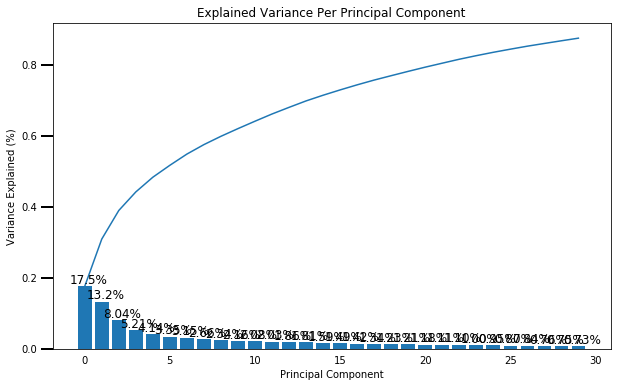

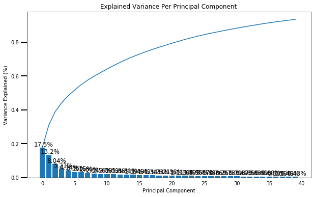

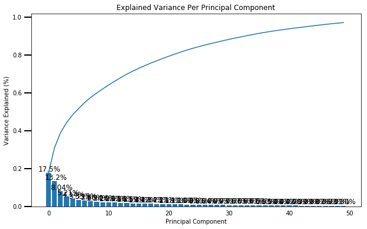

```python
# Investigate the variance accounted for by each principal component.
scree_plot(pca_1)
scree_plot(pca_2)
scree_plot(pca_3)
```

```python
# Re-apply PCA to the data while selecting for number of components to retain.
```

### Discussion 2.2: Perform Dimensionality Reduction

(Double-click this cell and replace this text with your own text, reporting your findings and decisions regarding dimensionality reduction. How many principal components / transformed features are you retaining for the next step of the analysis?)

### Answer:

1. I checked 3 values of components. It seems that even with a bit less than half of them, we can still get around 85% of the variablity of the data, so I'll retain the minimal number of 30 components for the next stage.
2. I didn't have to re-apply the PCA because I already have the PCA object for n=30 components

### Step 2.3: Interpret Principal Components

Now that we have our transformed principal components, it's a nice idea to check out the weight of each variable on the first few components to see if they can be interpreted in some fashion.

As a reminder, each principal component is a unit vector that points in the direction of highest variance (after accounting for the variance captured by earlier principal components). The further a weight is from zero, the more the principal component is in the direction of the corresponding feature. If two features have large weights of the same sign (both positive or both negative), then increases in one tend expect to be associated with increases in the other. To contrast, features with different signs can be expected to show a negative correlation: increases in one variable should result in a decrease in the other.

- To investigate the features, you should map each weight to their corresponding feature name, then sort the features according to weight. The most interesting features for each principal component, then, will be those at **the beginning and end of the sorted list**. Use the data dictionary document to help you understand these most prominent features, their relationships, and what a positive or negative value on the principal component might indicate.
- You should investigate and interpret feature associations from the first three principal components in this substep. To help facilitate this, you should write a function that you can call at any time to print the sorted list of feature weights, for the *i*-th principal component. This might come in handy in the next step of the project, when you interpret the tendencies of the discovered clusters.

```python
# HINT: Try defining a function here or in a new cell that you can reuse in the
# other cells.
def PrintSortedListOfFeatureWeightsForIthComponent( pca, i, columnNames ):
    ''' Input: pca - the PCA object
               i - The i"th component we want to print
               columnNames - The column names from the dataframe
        Output: printout of the sorted features list and their weight'''

    # Get weights for ith component
    comp_array = pca.components_[ i ]

    # Reshaping to 1D vector
    comp_array = comp_array.reshape( (1,comp_array.shape[0]))[0]

    # Get sorted INDICES (not values). We sort the ABSOLUTE values (because we're looking for large values, sign doesn't matter)
    # Additionally, argsort return from min->max, so flipping will give max->min (hence the [::-1])
    comp_idxs_sorted = np.argsort( np.abs(comp_array) )[::-1]

    # Get the names
    sortedColNames = columnNames[ comp_idxs_sorted ]

    # Printout
    print('PCA component %d - Features sorted according to their importance:' % ( i ) )
    q = 0
    for val in sortedColNames:
        print('%s. %s, weight: %2.4f' % ( q, val, comp_array[ comp_idxs_sorted[ q ] ] ) )
        q += 1
```

```python
# Map weights for the first principal component to corresponding feature names
# and then print the linked values, sorted by weight.
PrintSortedListOfFeatureWeightsForIthComponent( pca_1, 0, df.columns )
```

```
PCA component 0 - Features sorted according to their importance:
0. MOBI_REGIO, weight: -0.2384
1. PLZ8_ANTG3, weight: 0.2291
2. PLZ8_ANTG1, weight: -0.2278
3. PLZ8_ANTG4, weight: 0.2231
4. KBA05_ANTG1, weight: -0.2209
5. PLZ8_BAUMAX, weight: 0.2183
6. KBA05_GBZ, weight: -0.2141
7. ORTSGR_KLS9, weight: 0.2042
8. EWDICHTE, weight: 0.2017
9. FINANZ_MINIMALIST, weight: -0.2014
10. HH_EINKOMMEN_SCORE, weight: 0.1945
11. KONSUMNAEHE, weight: -0.1713
12. INNENSTADT, weight: -0.1694
13. PLZ8_GBZ, weight: -0.1693
14. FINANZ_HAUSBAUER, weight: 0.1642
15. PLZ8_ANTG2, weight: 0.1557
16. KBA05_ANTG4, weight: 0.1520
17. CAMEO_INTL_2015_WEALTH, weight: 0.1503
18. LP_LEBENSPHASE_FEIN, weight: -0.1452
19. ARBEIT, weight: 0.1447
20. RELAT_AB, weight: 0.1367
21. ANZ_HAUSHALTE_AKTIV, weight: 0.1350
22. BALLRAUM, weight: -0.1318
23. KBA05_ANTG3, weight: 0.1316
24. LP_LEBENSPHASE_GROB, weight: -0.1307
25. GEBAEUDETYP_RASTER, weight: -0.1201
26. FINANZ_SPARER, weight: 0.1173
27. CAMEO_INTL_2015_LSTAGE, weight: -0.1134
28. ANZ_PERSONEN, weight: -0.0946
29. WOHNLAGE, weight: -0.0921
30. PRAEGENDE_JUGENDJAHRE_MOVEMENT, weight: -0.0915
31. ALTERSKATEGORIE_GROB, weight: -0.0911
32. FINANZ_VORSORGER, weight: -0.0884
33. SEMIO_PFLICHT, weight: 0.0883
34. SEMIO_REL, weight: 0.0861
35. KBA13_ANZAHL_PKW, weight: -0.0793
36. PRAEGENDE_JUGENDJAHRE_DECADE, weight: 0.0736
37. SEMIO_RAT, weight: 0.0717
38. REGIOTYP, weight: 0.0647
```

[output cut: 11 more lines]

```
50. FINANZ_UNAUFFAELLIGER, weight: 0.0516
51. PLZ8_HHZ, weight: 0.0434
52. SEMIO_KAEM, weight: 0.0420
53. FINANZ_ANLEGER, weight: 0.0411
54. SEMIO_VERT, weight: -0.0381
55. SEMIO_SOZ, weight: 0.0376
56. ANZ_HH_TITEL, weight: 0.0365
57. KKK, weight: 0.0333
58. VERS_TYP, weight: 0.0276
59. SEMIO_DOM, weight: 0.0256
60. HEALTH_TYP, weight: 0.0252
61. SEMIO_KRIT, weight: 0.0112
62. KBA05_ANTG2, weight: 0.0075
63. ANZ_TITEL, weight: -0.0025
64. RETOURTYP_BK_S, weight: -0.0016
```

```python
# Map weights for the second principal component to corresponding feature names
# and then print the linked values, sorted by weight.
PrintSortedListOfFeatureWeightsForIthComponent( pca_1, 1, df.columns )
```

```
PCA component 1 - Features sorted according to their importance:
0. ALTERSKATEGORIE_GROB, weight: 0.2760
1. PRAEGENDE_JUGENDJAHRE_DECADE, weight: -0.2665
2. SEMIO_REL, weight: -0.2607
3. FINANZ_SPARER, weight: -0.2566
4. FINANZ_VORSORGER, weight: 0.2492
5. SEMIO_PFLICHT, weight: -0.2441
6. SEMIO_TRADV, weight: -0.2438
7. FINANZ_UNAUFFAELLIGER, weight: -0.2388
8. SEMIO_ERL, weight: 0.2251
9. FINANZ_ANLEGER, weight: -0.2231
10. SEMIO_KULT, weight: -0.2103
11. SEMIO_RAT, weight: -0.1939
12. SEMIO_LUST, weight: 0.1934
13. SEMIO_FAM, weight: -0.1747
14. RETOURTYP_BK_S, weight: 0.1705
15. SEMIO_MAT, weight: -0.1669
16. ONLINE_AFFINITAET, weight: -0.1621
17. W_KEIT_KIND_HH, weight: 0.1221
18. FINANZ_MINIMALIST, weight: 0.1018
19. SEMIO_KRIT, weight: 0.0971
20. FINANZ_HAUSBAUER, weight: 0.0930
21. SEMIO_SOZ, weight: -0.0898
22. SEMIO_KAEM, weight: 0.0843
23. EWDICHTE, weight: 0.0709
24. ORTSGR_KLS9, weight: 0.0697
25. PLZ8_ANTG3, weight: 0.0676
26. WOHNDAUER_2008, weight: 0.0670
27. PLZ8_ANTG1, weight: -0.0649
28. PLZ8_ANTG4, weight: 0.0645
29. HEALTH_TYP, weight: -0.0612
30. KBA05_GBZ, weight: -0.0608
31. PLZ8_BAUMAX, weight: 0.0599
32. MOBI_REGIO, weight: -0.0587
33. INNENSTADT, weight: -0.0565
34. ANZ_PERSONEN, weight: -0.0560
35. CAMEO_INTL_2015_WEALTH, weight: 0.0542
36. PLZ8_GBZ, weight: -0.0528
37. ARBEIT, weight: 0.0514
38. KONSUMNAEHE, weight: -0.0512
```

[output cut: 11 more lines]

```
50. VERS_TYP, weight: 0.0318
51. GEBAEUDETYP_RASTER, weight: -0.0311
52. HH_EINKOMMEN_SCORE, weight: 0.0284
53. KBA13_ANZAHL_PKW, weight: -0.0275
54. ANZ_HH_TITEL, weight: 0.0274
55. KBA05_ANTG3, weight: 0.0257
56. LP_LEBENSPHASE_FEIN, weight: -0.0252
57. OST_WEST_KZ, weight: -0.0195
58. CAMEO_INTL_2015_LSTAGE, weight: 0.0190
59. KBA05_ANTG2, weight: -0.0109
60. REGIOTYP, weight: 0.0108
61. PLZ8_HHZ, weight: 0.0085
62. ANZ_TITEL, weight: 0.0081
63. KKK, weight: -0.0041
64. PRAEGENDE_JUGENDJAHRE_MOVEMENT, weight: 0.0038
```

```python
# Map weights for the third principal component to corresponding feature names
# and then print the linked values, sorted by weight.
PrintSortedListOfFeatureWeightsForIthComponent( pca_1, 2, df.columns )
```

```
PCA component 2 - Features sorted according to their importance:
0. SEMIO_VERT, weight: 0.3761
1. SEMIO_KAEM, weight: -0.3706
2. SEMIO_DOM, weight: -0.3465
3. SEMIO_KRIT, weight: -0.3106
4. SEMIO_SOZ, weight: 0.2934
5. SEMIO_FAM, weight: 0.2853
6. SEMIO_KULT, weight: 0.2708
7. SEMIO_RAT, weight: -0.2140
8. SEMIO_ERL, weight: -0.2106
9. FINANZ_ANLEGER, weight: -0.1866
10. FINANZ_MINIMALIST, weight: 0.1679
11. RETOURTYP_BK_S, weight: 0.1015
12. SEMIO_REL, weight: 0.1009
13. FINANZ_SPARER, weight: -0.0981
14. PRAEGENDE_JUGENDJAHRE_DECADE, weight: -0.0974
15. FINANZ_VORSORGER, weight: 0.0916
16. FINANZ_UNAUFFAELLIGER, weight: -0.0881
17. W_KEIT_KIND_HH, weight: 0.0844
18. SEMIO_MAT, weight: 0.0772
19. SEMIO_PFLICHT, weight: -0.0606
20. SEMIO_TRADV, weight: -0.0599
21. FINANZ_HAUSBAUER, weight: -0.0592
22. ALTERSKATEGORIE_GROB, weight: 0.0575
23. SEMIO_LUST, weight: 0.0537
24. PRAEGENDE_JUGENDJAHRE_MOVEMENT, weight: 0.0521
25. ONLINE_AFFINITAET, weight: -0.0403
26. PLZ8_BAUMAX, weight: 0.0396
27. PLZ8_ANTG4, weight: 0.0362
28. ORTSGR_KLS9, weight: 0.0359
29. PLZ8_ANTG1, weight: -0.0359
30. EWDICHTE, weight: 0.0352
31. INNENSTADT, weight: -0.0350
32. WOHNDAUER_2008, weight: 0.0342
33. PLZ8_ANTG3, weight: 0.0342
34. HH_EINKOMMEN_SCORE, weight: -0.0341
35. PLZ8_GBZ, weight: -0.0323
36. KONSUMNAEHE, weight: -0.0299
37. HEALTH_TYP, weight: -0.0296
38. BALLRAUM, weight: -0.0285
```

[output cut: 9 more lines]

```
48. WOHNLAGE, weight: -0.0141
49. KBA05_ANTG2, weight: -0.0131
50. MIN_GEBAEUDEJAHR, weight: -0.0130
51. KBA05_GBZ, weight: -0.0124
52. LP_LEBENSPHASE_FEIN, weight: 0.0114
53. ANZ_HH_TITEL, weight: 0.0112
54. CAMEO_INTL_2015_WEALTH, weight: 0.0110
55. ANZ_TITEL, weight: 0.0103
56. REGIOTYP, weight: -0.0101
57. KBA05_ANTG1, weight: -0.0091
58. LP_LEBENSPHASE_GROB, weight: 0.0083
59. CAMEO_INTL_2015_LSTAGE, weight: -0.0043
60. ANZ_PERSONEN, weight: 0.0034
61. KBA05_ANTG3, weight: -0.0014
62. PLZ8_HHZ, weight: 0.0010
```

### Discussion 2.3: Interpret Principal Components

(Double-click this cell and replace this text with your own text, reporting your observations from detailed investigation of the first few principal components generated. Can we interpret positive and negative values from them in a meaningful way?)

### Answer:

Yes. I think I can interpert in a meaningful way. There are A LOT of insights you can get from the data. I feel like i'm in the matrix! ;) I'll describe my observation from each principal component and within the description explain about negative/positive values. **I apologize for the longevity of my answer.**

1. Seems that the most dominant coefficients for the linear combination making this component are (by order):MOBI_REGIO-, PLZ8_ANTG3+, PLZ8_ANTG1-, PLZ8_ANTG4+, KBA05_ANTG1-, PLZ8_BAUMAX+, KBA05_GBZ-, ORTSGR_KLS9+, FINANZ_MINIMALIST-, EWDICHTE+, HH_EINKOMMEN_SCORE+, KONSUMNAEHE-, INNENSTADT-, PLZ8_GBZ-. (The '+' or '-' signs indicate positive/negative correlation. Positive means that when the feature value increases so is the component value. Negative means the opposite. (Feature increase, pca component drops). **Seems like main related features here are from the cellular MACRO cell.**
   - MOBI_REGIO- for example: The higher the value means lower (pedestrian?) movement in the area. However, negative correlation means that our PCA component is higher for low values of MOBI_REGIO, so high movement --> High PCA component. **PCA component is large in areas with high volumes of pedestrians walking around.**
   - PLZ8_ANTG3+, PLZ8_ANTG1-, PLZ8_ANTG4+, KBA05_ANTG1-, PLZ8_BAUMAX+, KBA05_GBZ-, ORTSGR_KLS9+, EWDICHTE --> All of these are related to the density of the population in the area, some correlated positively and some negatively. Let's check one example: PLZ8_ANTG3 high == high share of 6-10 family homes. PLZ8_ANTG1 low == no 1-2 family homes. This means that our PCA component is affected by **density** of family homes in area. A high density of 6-10 homes means a low/none 1-2 family homes, so that's why the signs are opposites. But the main idea is that our **PCA component is large in areas with a high population density.**
   - The other values are related to income (high income - high PCA component), distance from city center (farther away, less to the component), etc..
2. Without writing again all the values, my insights here are:
   - Age (ALTERSKATEGORIE_GROB and PRAEGENDE_JUGENDJAHRE_DECADE are inverses of each other. The higher the age means lower decade. In any case, the higher the age, the higher the PCA component.
   - Charachter traits, such as affinity to money saving or investing (negative correlation), or how religious (low value means highest affinity, and since negative correlation, this means this PCA component tells us a bit how religious, dutiful and religious a person is)
3. The 3rd component is highly related to charchter of people. It will increase for the following traits: KAEM, DOM, KRIT, RAT, ERL which are: combative attitude, dominant-minded, critical-minded, rational, event-oriented. It will decrease for the traits: VERT, SOZ, FAM, KULT: dreamful, socially-minded, family-minded, cultural-minded. So, i'd say this component is related to how "practical, focused and goal oriented" people are. High values indicate these types of traits in the people. Low values are more "la la land" people.

**I have to admit that during this analysis I really got the grasp of "Data is power" (in contrast to knowledge is..). This is truly amazing that we can extract such insights from databases.. I really liked this! If I didn't write nonsense I like it even more!!!**

## Step 3: Clustering

### Step 3.1: Apply Clustering to General Population

You've assessed and cleaned the demographics data, then scaled and transformed them. Now, it's time to see how the data clusters in the principal components space. In this substep, you will apply k-means clustering to the dataset and use the average within-cluster distances from each point to their assigned cluster's centroid to decide on a number of clusters to keep.

- Use sklearn's KMeans class to perform k-means clustering on the PCA-transformed data.
- Then, compute the average difference from each point to its assigned cluster's center. **Hint**: The KMeans object's `.score()` method might be useful here, but note that in sklearn, scores tend to be defined so that larger is better. Try applying it to a small, toy dataset, or use an internet search to help your understanding.
- Perform the above two steps for a number of different cluster counts. You can then see how the average distance decreases with an increasing number of clusters. However, each additional cluster provides a smaller net benefit. Use this fact to select a final number of clusters in which to group the data. **Warning**: because of the large size of the dataset, it can take a long time for the algorithm to resolve. The more clusters to fit, the longer the algorithm will take. You should test for cluster counts through at least 10 clusters to get the full picture, but you shouldn't need to test for a number of clusters above about 30.
- Once you've selected a final number of clusters to use, re-fit a KMeans instance to perform the clustering operation. Make sure that you also obtain the cluster assignments for the general demographics data, since you'll be using them in the final Step 3.3.

```python
# Over a number of different cluster counts...
min_num_clusters = 20
max_num_clusters = 30
for k in range( min_num_clusters, max_num_clusters):
    print('Clustering for k=%d...' % (k))
    kmeans = KMeans(n_clusters=k)

    # run k-means clustering on the data and...
    model = kmeans.fit(pca_1_ndarray)

    # compute the average within-cluster distances.
    score.append( np.abs(model.score(pca_1_ndarray) ) )
    print( 'score : %7.7f' % ( score[-1] ) )
```

```
Clustering for k=20...
score : 23334626.6286090
Clustering for k=21...
score : 23124280.0598400
Clustering for k=22...
score : 23002271.7996393
Clustering for k=23...
score : 22845819.4789893
Clustering for k=24...
score : 22624349.0759339
Clustering for k=25...
score : 22402786.8649831
Clustering for k=26...
score : 22188781.0444274
Clustering for k=27...
score : 22057904.2086220
Clustering for k=28...
score : 21910671.0067384
Clustering for k=29...
```

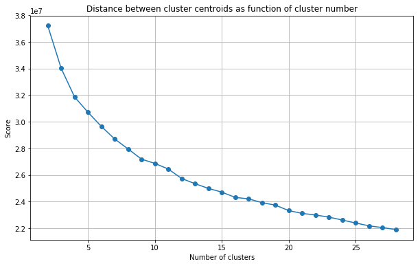

```python
# Investigate the change in within-cluster distance across number of clusters.
# HINT: Use matplotlib's plot function to visualize this relationship.
# NOTICE: I ran in blocks. At first from 2-10, then 10-19, and in the end, I didn't see a clear knee so 20-29. Above you see
# the results only for the last trial I did..
scores_list = [ 37213321.3178708, 34024534.9143600, 31871774.0244776, 30723345.9803277, 29658898.3480890, \
               28711100.7205954, 27962407.8038171, 27198514.3079079, 26878915.4504958, 26456070.1619354, \
               25744630.9326722, 25354719.7607003, 25001751.6841192, 24721369.2839459, 24325870.7333525, \
              24216056.9940939, 23931458.3905894, 23743054.6413222, 23334626.6286090, 23124280.0598400, \
              23002271.7996393, 22845819.4789893, 22624349.0759339, 22402786.8649831, 22188781.0444274, \
              22057904.2086220, 21910671.0067384]
clusters_vec = range(2, 29)
plt.figure(figsize=(10, 6))
ax = plt.subplot(111)
ax.plot(clusters_vec, scores_list, '-o')
ax.set_xlabel("Number of clusters")
ax.set_ylabel("Score")
plt.title('Distance between cluster centroids as function of cluster number')
ax.grid()
```

```python
# Re-fit the k-means model with the selected number of clusters and obtain
# cluster predictions for the general population demographics data.
k = 10
kmeans = KMeans(n_clusters = k)
model = kmeans.fit( pca_1_ndarray )
labels = model.predict( pca_1_ndarray )
labels_centroids = model.cluster_centers_ # Get centroids. We'll use that later
```

### Step 3.2: Apply All Steps to the Customer Data

Now that you have clusters and cluster centers for the general population, it's time to see how the customer data maps on to those clusters. Take care to not confuse this for re-fitting all of the models to the customer data. Instead, you're going to use the fits from the general population to clean, transform, and cluster the customer data. In the last step of the project, you will interpret how the general population fits apply to the customer data.

- Don't forget when loading in the customers data, that it is semicolon (`;`) delimited.
- Apply the same feature wrangling, selection, and engineering steps to the customer demographics using the `clean_data()` function you created earlier. (You can assume that the customer demographics data has similar meaning behind missing data patterns as the general demographics data.)
- Use the sklearn objects from the general demographics data, and apply their transformations to the customers data. **That is, you should not be using a `.fit()` or `.fit_transform()` method to re-fit the old objects, nor should you be creating new sklearn objects!** Carry the data through the feature scaling, PCA, and clustering steps, obtaining cluster assignments for all of the data in the customer demographics data.

```python
# Load in the customer demographics data.
df_cust = pd.read_csv('Udacity_CUSTOMERS_Subset.csv', sep=';')
```

```python
# Apply preprocessing, feature transformation, and clustering from the general
# demographics onto the customer data, obtaining cluster predictions for the
# customer demographics data.

# Data wrangling
df_cust = clean_data(df_cust)

# Imputing
df_cust_columns = df_cust.columns
df_cust_indices = df_cust.index
df_cust = pd.DataFrame( imputer.transform( df_cust ) )
df_cust.columns = df_cust_columns
df_cust.index = df_cust_indices
print('Finished Imputing...')

# Scaling
df_cust[df_cust.columns] = scaler.transform(df_cust[df_cust.columns])
print('Finished Scaling...')

# PCA
pca_1_ndarray_cust = pca_1.transform(df_cust)
print('Finished PCA...')

# K-means
labels_cust = model.predict(pca_1_ndarray_cust)
print('Finished K-means prediction...')
```

[output not shown]

[output cut: 34 more lines]

[output not shown]

### Step 3.3: Compare Customer Data to Demographics Data

At this point, you have clustered data based on demographics of the general population of Germany, and seen how the customer data for a mail-order sales company maps onto those demographic clusters. In this final substep, you will compare the two cluster distributions to see where the strongest customer base for the company is.

Consider the proportion of persons in each cluster for the general population, and the proportions for the customers. If we think the company's customer base to be universal, then the cluster assignment proportions should be fairly similar between the two. If there are only particular segments of the population that are interested in the company's products, then we should see a mismatch from one to the other. If there is a higher proportion of persons in a cluster for the customer data compared to the general population (e.g. 5% of persons are assigned to a cluster for the general population, but 15% of the customer data is closest to that cluster's centroid) then that suggests the people in that cluster to be a target audience for the company. On the other hand, the proportion of the data in a cluster being larger in the general population than the customer data (e.g. only 2% of customers closest to a population centroid that captures 6% of the data) suggests that group of persons to be outside of the target demographics.

Take a look at the following points in this step:

- Compute the proportion of data points in each cluster for the general population and the customer data. Visualizations will be useful here: both for the individual dataset proportions, but also to visualize the ratios in cluster representation between groups. Seaborn's [`countplot()`](https://seaborn.pydata.org/generated/seaborn.countplot.html) or [`barplot()`](https://seaborn.pydata.org/generated/seaborn.barplot.html) function could be handy.
  - Recall the analysis you performed in step 1.1.3 of the project, where you separated out certain data points from the dataset if they had more than a specified threshold of missing values. If you found that this group was qualitatively different from the main bulk of the data, you should treat this as an additional data cluster in this analysis. Make sure that you account for the number of data points in this subset, for both the general population and customer datasets, when making your computations!
- Which cluster or clusters are overrepresented in the customer dataset compared to the general population? Select at least one such cluster and infer what kind of people might be represented by that cluster. Use the principal component interpretations from step 2.3 or look at additional components to help you make this inference. Alternatively, you can use the `.inverse_transform()` method of the PCA and StandardScaler objects to transform centroids back to the original data space and interpret the retrieved values directly.
- Perform a similar investigation for the underrepresented clusters. Which cluster or clusters are underrepresented in the customer dataset compared to the general population, and what kinds of people are typified by these clusters?

```
Text(0.5,1,'Cluster sizes proportions. Blue = general population, red = customer database')
```

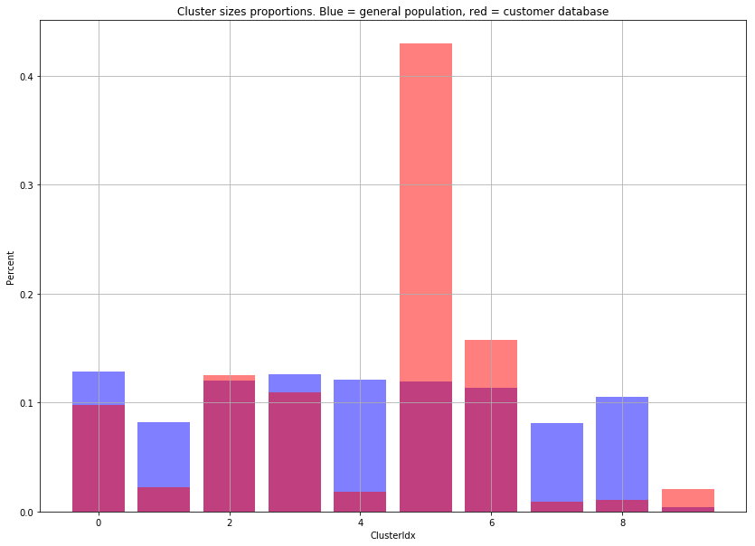

```python
# Compare the proportion of data in each cluster for the customer data to the
# proportion of data in each cluster for the general population.

# Init
prop_array_gen = []
prop_array_cust = [];

# Calc proportion of clusters for general population
for clusterIdx in range(0,k):
    prop_array_gen.append( np.count_nonzero( labels == clusterIdx ) / len( labels ) )

# Calc proportion of clusters for customer population
for clusterIdx in range(0,k):
    prop_array_cust.append( np.count_nonzero( labels_cust == clusterIdx ) / len( labels_cust ) )

# Plots
fig, ax = plt.subplots()
fig.set_size_inches(14, 10)
plt.bar( range(0,k), prop_array_gen, color='b', alpha = 0.5 )
plt.bar( range(0,k), prop_array_cust, color='r', alpha = 0.5 )
ax.set(ylabel='Percent', xlabel='ClusterIdx')
ax.grid()
ax.set_title('Cluster sizes proportions. Blue = general population, red = customer database')
```

```python
# What kinds of people are part of a cluster that is overrepresented in the
# customer data compared to the general population?

# Cluster indices of 5,6,9 are overrepresented.
# Cluster 9 is a very small part of the general customer/population size, so I won't talk about it. Let's see what's going on
# with clusters 5,6.

# Let's get their centroid values
tmp = model.cluster_centers_

# Let's print the first 3 PCA components for cluster 5,6
print( 'Cluster Idx 5, 1st 3 components: %s' % (tmp[5,0:3]))
print( 'Cluster Idx 6, 1st 3 components: %s' % (tmp[6,0:3]))
```

```
Cluster Idx 5, 1st 3 components: [-2.93809776  0.63761203  2.30291249]
Cluster Idx 6, 1st 3 components: [-2.88735553  2.09903026 -1.67519931]
```

#### My analysis:

We can combine both insights and say, that in general, older people from less populated areas are the mail company customers.

```python
# What kinds of people are part of a cluster that is underrepresented in the
# customer data compared to the general population?

# Cluster indices of 1,4,7,8 are underrepresented. (Maybe 8 too, but it's less apparent)
# Let's get their centroid values
tmp = model.cluster_centers_

# Let's print the first 3 PCA components for cluster 1,4,7,8
print( 'Cluster Idx 1, 1st 3 components: %s' % (tmp[1,0:3]))
print( 'Cluster Idx 4, 1st 3 components: %s' % (tmp[4,0:3]))
print( 'Cluster Idx 7, 1st 3 components: %s' % (tmp[7,0:3]))
print( 'Cluster Idx 8, 1st 3 components: %s' % (tmp[8,0:3]))
```

```
Cluster Idx 1, 1st 3 components: [-1.34085761 -4.41911989  2.15889156]
Cluster Idx 4, 1st 3 components: [-1.01031824 -3.05242517 -2.57310212]
Cluster Idx 7, 1st 3 components: [ 4.25660176 -2.69875848  2.44560292]
Cluster Idx 8, 1st 3 components: [ 4.42800194 -1.56905794 -2.22896401]
```

#### My analysis:

Clusters 7:

- Component 1: large positive value == densely populated areas with high movement.
- Component 2: large negative value == Younger age / higher decade.
- Component 3: large positive value == Strongly rational, critical minded people.

Clusters 1:

- Component 1: negaive value == less populated areas with less movement.
- Component 2: large negative value == Younger age / higher decade
- Component 3: large positive value == Strongly rational, critical minded people.

Clusters 8:

- Component 1: large positive value == densely populated areas with high movement.
- Component 2: negative value == Younger age / higher decade
- Component 3: large negative value == More cultural, free spirited people.

Clusters 4:

- Component 1: negaive value == less populated areas with less movement.
- Component 2: large negative value == Younger age / higher decade
- Component 3: large negative value == More cultural, free spirited people.

So, a bit more complicated than before, the full analysis will be in discussion 3.3

### Discussion 3.3: Compare Customer Data to Demographics Data

(Double-click this cell and replace this text with your own text, reporting findings and conclusions from the clustering analysis. Can we describe segments of the population that are relatively popular with the mail-order company, or relatively unpopular with the company?)

### Answer:

I'll describe both popular and unpopular.

**Unpopular groups**: According to the PCA 1st 3 components of each cluster (1,4,7,8) I saw the following pattern:

- The densly populated areas of younger age (both "rational" and "free spirited") use the mail-order company less.
- In a similar way, for less populated areas and younger ages, again, both "free spirited" and "rational" people use the service less.

**Popular groups**: According to the PCA 1st 3 components of each cluster (5,6) I saw the following pattern: I actually explained before, but saying it again, most customers (by far! They are highly over represented in the customers database) seem to arrive from the less populated areas and are of older age and more established financially. One cluster contains the rational, dominant, critical thinkers. The other group contains the more socailly, dreamful, cultural minded. So, both groups have representation so it doesn't really matter, so basically, area of living and age count here.

> Congratulations on making it this far in the project! Before you finish, make sure to check through the entire notebook from top to bottom to make sure that your analysis follows a logical flow and all of your findings are documented in **Discussion** cells. Once you've checked over all of your work, you should export the notebook as an HTML document to submit for evaluation. You can do this from the menu, navigating to **File -> Download as -> HTML (.html)**. You will submit both that document and this notebook for your project submission.